# Tugas Praktikum 2 MPDW

Septiranny Rizqika Putri G1401211083

#Packages

```r
library(dplyr)
library(TTR)
library(forecast)
library(lmtest) #untuk uji formal deteksi autokorelasi
library(orcutt) #untuk buat model regresi Cochrane-Orcutt
library(HoRM) #untuk buat model regresi Hildreth-Lu
```

#Input data

Dataset yang digunakan adalah data penjualan mingguan obat sejak 1 Januari 2014 hingga 13 Oktober 2019.

```r
library(readr)
data <- read_csv("salesweekly.csv")
data
```

```
## # A tibble: 302 × 9
##    datum     M01AB M01AE N02BA N02BE  N05B  N05C   R03   R06
##    <chr>     <dbl> <dbl> <dbl> <dbl> <dbl> <dbl> <dbl> <dbl>
##  1 1/5/2014   14    11.7  21.3  186.    41     0    32   7
##  2 1/12/2014  29.3  12.7  37.9  191.    88     5    21   7.2
##  3 1/19/2014  30.7  26.3  45.9  218.    80     8    29  12
##  4 1/26/2014  34    32.4  31.5  180.    80     8    23  10
##  5 2/2/2014   31.0  23.4  20.7  160.    84    12    29  12
##  6 2/9/2014   22.6  29.7  53.3  227.    98     7    31   6
##  7 2/16/2014  33.3  30.7  47.3  321.    89    14    18  16.2
##  8 2/23/2014  39.0  34.2  44.2  233.    99     5    35   7
##  9 3/2/2014   36.7  28.8  40.4  222.    52     2    16  10.1
## 10 3/9/2014   25.0  21.1  31.8  202.    48     4    16   9.2
## # ℹ 292 more rows
```

Pada dataset mentah, terdapat beberapa variabel (jenis obat). Dalam hal ini, peubah yang akan digunakan adalah penjualan obat analgesik salicylic acid (N02BA).

```r
penjualan <- as.data.frame(data[,4])
penjualan
```

```
##        N02BA
## 1   21.30000
## 2   37.90000
## 3   45.90000
## 4   31.50000
## 5   20.70000
## 6   53.30000
## 7   47.30000
## 8   44.20000
## 9   40.35500
## 10  31.80000
## 11  36.20000
## 12  26.10000
## 13  36.20000
## 14  36.40000
```

[output cut: 288 more lines]

Meski disebut data mingguan, amatan pertama bukan hasil amatan selama satu pekan penuh (7 hari), karena 1 Januari 2014 jatuh di hari Rabu, dan peneliti melakukan pencatatan tiap hari Minggu. Karena amatan pertama periodenya tidak seragam (hanya 5 hari), data yang digunakan akan dipotong.

Data yang digunakan merupakan data 1 September 2014 (jatuh di hari Senin, sehingga periode amatannya 7 hari) hingga 13 Oktober 2019 dengan jumlah 267 amatan (267 pekan).

```r
penjualan <- penjualan[36:302,]
penjualan <- as.data.frame(penjualan)
penjualan
```

```
##     penjualan
## 1    23.60000
## 2    22.40000
## 3    28.70000
## 4    31.10000
## 5    30.60000
## 6    33.10000
## 7    28.33750
## 8    25.20000
## 9    34.10000
## 10   29.80000
## 11   31.30000
## 12   37.50000
## 13   39.60000
## 14   18.30000
```

[output cut: 253 more lines]

Peubah ‘datum’ di data mentah menunjukkan tanggal pencatatan. Akan diubah penyajiannya dalam bentuk ‘pekan ke-’

```r
pekan <- c(seq(1:267))
data <- as.data.frame(cbind(pekan,penjualan))
data
```

```
##     pekan penjualan
## 1       1  23.60000
## 2       2  22.40000
## 3       3  28.70000
## 4       4  31.10000
## 5       5  30.60000
## 6       6  33.10000
## 7       7  28.33750
## 8       8  25.20000
## 9       9  34.10000
## 10     10  29.80000
## 11     11  31.30000
## 12     12  37.50000
## 13     13  39.60000
## 14     14  18.30000
```

[output cut: 253 more lines]

#Eksplorasi data

Melihat struktur data

```r
str(data)
```

```
## 'data.frame':    267 obs. of  2 variables:
##  $ pekan    : int  1 2 3 4 5 6 7 8 9 10 ...
##  $ penjualan: num  23.6 22.4 28.7 31.1 30.6 ...
```

Melihat dimensi/ukuran data

```r
dim(data)
```

```
## [1] 267   2
```

Membuat data terbaca sebagai data time series

```r
datats <- ts(data$penjualan)
```

Menampilkan plot time series data

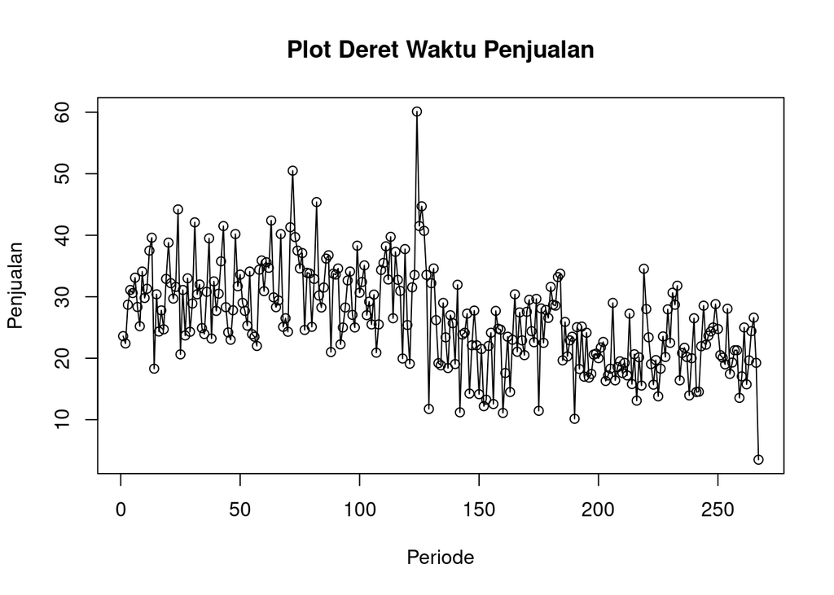

```r
ts.plot(datats, xlab="Periode", ylab="Penjualan", main= "Plot Deret Waktu Penjualan")
points(datats)
```

#Pemulusan dengan DMA

Pemulusan dengan metode DMA dengan parameter m=6. Peramalan untuk 50 periode ke depan

```r
dt.sma <- SMA(datats, n=6)
dma <- SMA(dt.sma, n=6)
At <- 2*dt.sma - dma
Bt <- 2/(6-1)*(dt.sma - dma)
dt.dma<- At+Bt
dt.ramal<- c(NA, dt.sma)

t = 1:50
f = c()

for (i in t) {
  f[i] = At[length(At)] + Bt[length(Bt)]*(i)
}
```

```r
dt.gab <- cbind(aktual = c(datats,rep(NA,50)),
                pemulusan1 = c(dt.sma,rep(NA,50)),
                pemulusan2 = c(dt.dma, rep(NA,50)),
                At = c(At, rep(NA,50)),
                Bt = c(Bt,rep(NA,5)),
                ramalan = c(dt.ramal, f[-1]))
dt.gab
```

```
##          aktual pemulusan1 pemulusan2       At           Bt     ramalan
##   [1,] 23.60000         NA         NA       NA           NA          NA
##   [2,] 22.40000         NA         NA       NA           NA          NA
##   [3,] 28.70000         NA         NA       NA           NA          NA
##   [4,] 31.10000         NA         NA       NA           NA          NA
##   [5,] 30.60000         NA         NA       NA           NA          NA
##   [6,] 33.10000   28.25000         NA       NA           NA          NA
##   [7,] 28.33750   29.03958         NA       NA           NA  28.2500000
##   [8,] 25.20000   29.50625         NA       NA           NA  29.0395833
##   [9,] 34.10000   30.40625         NA       NA           NA  29.5062500
##  [10,] 29.80000   30.18958         NA       NA           NA  30.4062500
##  [11,] 31.30000   30.30625   31.27215 30.99618  0.275972222  30.1895833
##  [12,] 37.50000   31.03958   32.38125 31.99792  0.383333333  30.3062500
##  [13,] 39.60000   32.91667   35.98160 35.10590  0.875694444  31.0395833
##  [14,] 18.30000   31.76667   32.69417 32.42917  0.265000000  32.9166667
```

[output cut: 303 more lines]

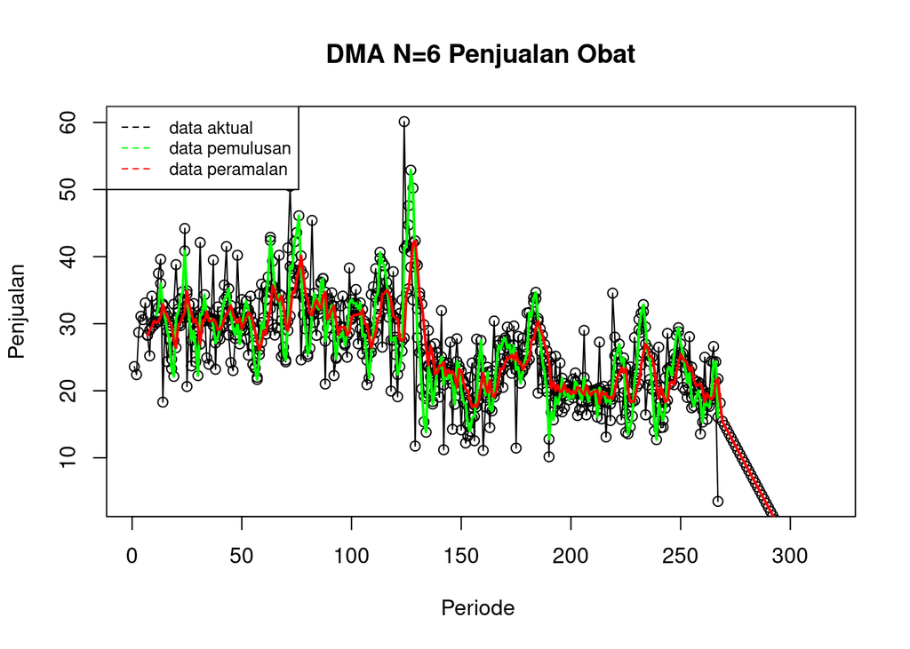

```r
#Plot time series
ts.plot(dt.gab[,1], xlab="Periode ", ylab="Penjualan",
        main= "DMA N=6 Penjualan Obat")
points(dt.gab[,1])
points(dt.gab[,3])
points(dt.gab[,6])
lines(dt.gab[,3],col="green",lwd=2)
lines(dt.gab[,6],col="red",lwd=2)
legend("topleft",c("data aktual","data pemulusan","data peramalan"),
       lty=8, col=c("black","green","red"), cex=0.8)
```

##Akurasi metode DMA

```r
#Menghitung nilai keakuratan
error.dma = datats-dt.ramal[1:length(datats)]
SSE.dma = sum(error.dma[7:length(datats)]^2)
MSE.dma = mean(error.dma[7:length(datats)]^2)
MAPE.dma = mean(abs((error.dma[7:length(datats)]/datats[7:length(datats)])*100))

akurasi.dma <- matrix(c(SSE.dma, MSE.dma, MAPE.dma))
row.names(akurasi.dma)<- c("SSE", "MSE", "MAPE")
colnames(akurasi.dma) <- c("Akurasi m = 6")
akurasi.dma
```

```
##      Akurasi m = 6
## SSE    12471.89176
## MSE       47.78503
## MAPE      24.48641
```

#Pemulusan dengan DSE

##Pembagian data

Pembagian data dengan komposisi 80% data latih dan 20% data uji

```r
#Bagi data
train<-data[1:213,2]
test<-data[214:267,2]

#Buat agar terbaca sebagai data time series
train.ts <- ts(train)
test.ts <- ts(test, start=214)

#Eksplorasi data
par(nfrow=c(1,2))
```

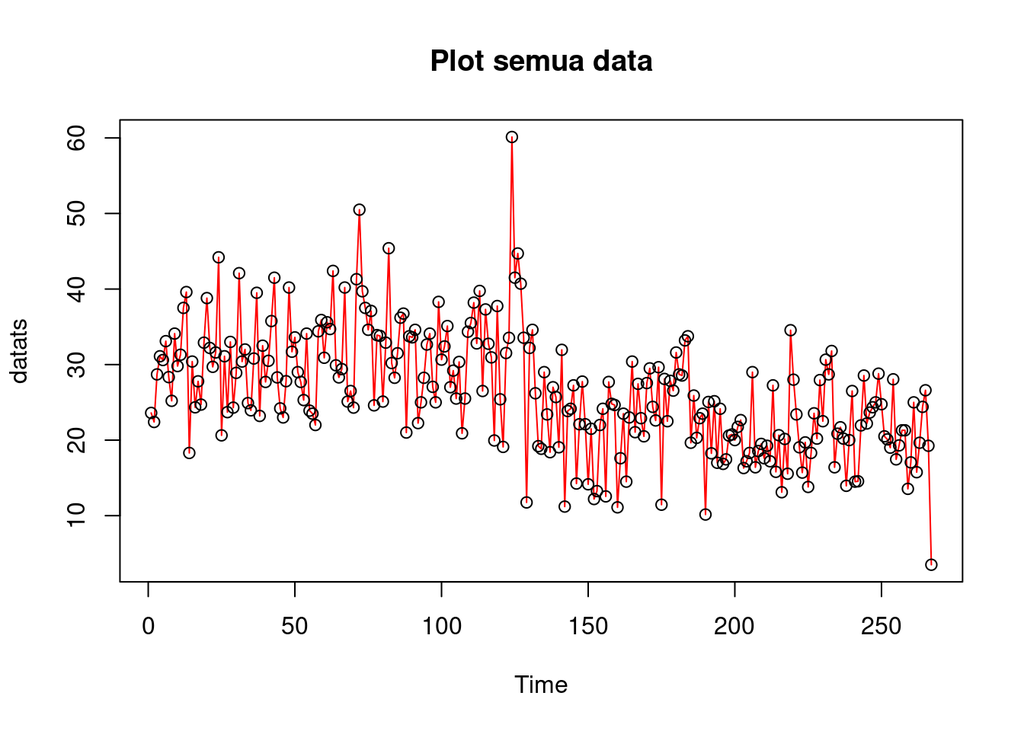

```r
plot(datats, col="red",main="Plot semua data")
points(datats)
```

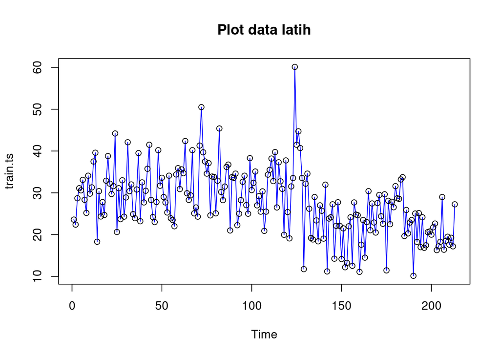

```r
plot(train.ts, col="blue",main="Plot data latih")
points(train.ts)
```

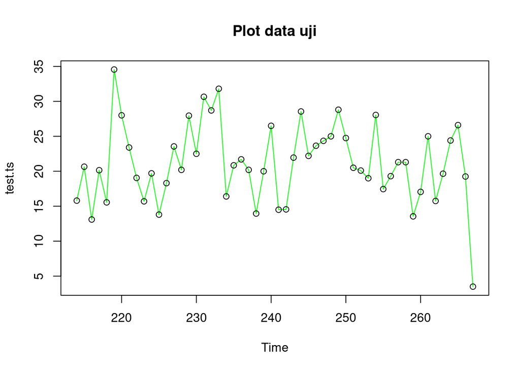

```r
plot(test.ts, col="green",main="Plot data uji")
points(test.ts)
```

##Pemulusan

Pemulusan dengan metode DSE dengan parameter lambda dan gamma optimal

```r
#Lambda dan gamma optimum
des.opt<- HoltWinters(train.ts, gamma=FALSE)
des.opt
```

```
## Holt-Winters exponential smoothing with trend and without seasonal component.
##
## Call:
## HoltWinters(x = train.ts, gamma = FALSE)
##
## Smoothing parameters:
##  alpha: 0.2360553
##  beta : 0.04675894
##  gamma: FALSE
##
## Coefficients:
##          [,1]
## a 20.31574348
## b -0.05207095
```

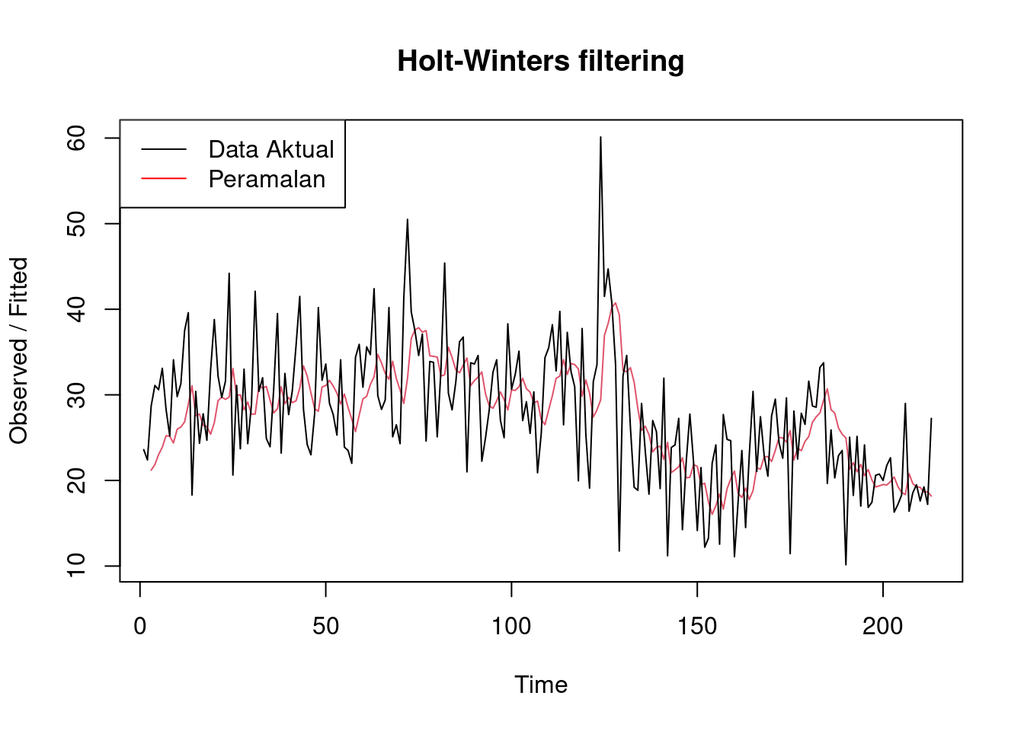

```r
plot(des.opt)
legend("topleft", c("Data Aktual", "Peramalan"), col = c("black", "red"),
       lty = c(1,1))
```

```r
#ramalan
ramalan.desopt<- forecast(des.opt, h=5)
ramalan.desopt
```

```
##     Point Forecast     Lo 80    Hi 80    Lo 95    Hi 95
## 214       20.26367 11.299240 29.22811 6.553756 33.97359
## 215       20.21160 10.977562 29.44564 6.089356 34.33385
## 216       20.15953 10.639968 29.67909 5.600616 34.71844
## 217       20.10746 10.286851 29.92807 5.088135 35.12678
## 218       20.05539  9.918627 30.19215 4.552550 35.55823
```

##Akurasi metode DSE

Akurasi data latih

```r
#Akurasi data latih
ssedes.train <- des.opt$SSE
msedes.train <- ssedes.train/length(train.ts)
sisaandes <- ramalan.desopt$residuals
head(sisaandes)
```

```
## Time Series:
## Start = 1
## End = 6
## Frequency = 1
## [1]       NA       NA 7.500000 9.246803 7.579200 9.221587
```

```r
mapedes.train <- sum(abs(sisaandes[3:length(train.ts)]/train.ts[3:length(train.ts)])*100)/length(train.ts)

akurasides.opt <- matrix(c(ssedes.train,msedes.train,mapedes.train))
row.names(akurasides.opt)<- c("SSE", "MSE", "MAPE")
colnames(akurasides.opt) <- c("Akurasi lambda dan gamma optimum")
akurasides.opt
```

```
##      Akurasi lambda dan gamma optimum
## SSE                       10326.51963
## MSE                          48.48131
## MAPE                         21.75206
```

Akurasi data latih dengan metode DSE memiliki nilai MAPE 21,75%. Ini menunjukkan bahwa akurasinya cukup baik.

Akurasi data uji

```r
#Akurasi data uji
selisihdesopt<-ramalan.desopt$mean-test.ts
selisihdesopt
```

```
## Time Series:
## Start = 214
## End = 218
## Frequency = 1
## [1]  4.46367253 -0.43839842  7.05953063 -0.04254032  4.50538873
```

```r
SSEtestingdesopt<-sum(selisihdesopt^2)
SSEtestingdesopt<-SSEtestingdesopt/length(test.ts)
MAPEtestingdesopt<-sum(abs(selisihdesopt/test.ts)*100)/length(test.ts)

akurasiDesTesting <- matrix(c(SSEtestingdesopt,SSEtestingdesopt,MAPEtestingdesopt))
row.names(akurasiDesTesting)<- c("SSE", "MSE", "MAPE")
colnames(akurasiDesTesting) <- c("Akurasi lamda dan gamma optimum")
akurasiDesTesting
```

```
##      Akurasi lamda dan gamma optimum
## SSE                         1.671368
## MSE                         1.671368
## MAPE                        2.100895
```

#Perbandingan akurasi

Perbandingan akurasi metode DMA dan DSE

```r
cbind(akurasi.dma, akurasiDesTesting)
```

```
##      Akurasi m = 6 Akurasi lamda dan gamma optimum
## SSE    12471.89176                        1.671368
## MSE       47.78503                        1.671368
## MAPE      24.48641                        2.100895
```

#Regresi

##Eksplorasi data

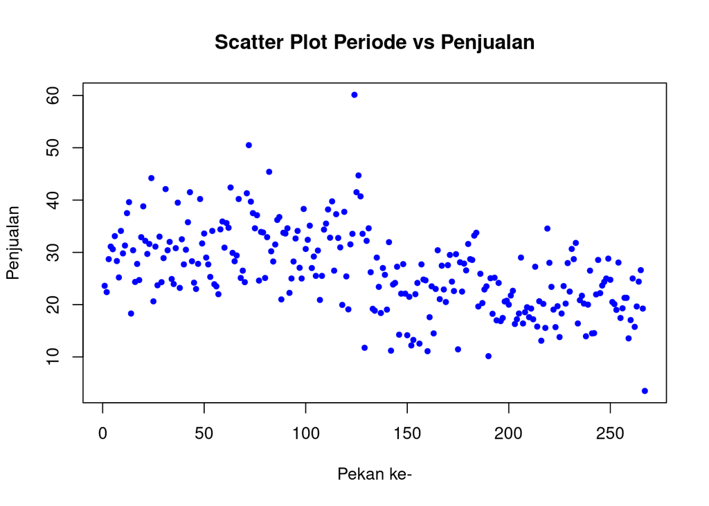

```r
#Scatter Plot
plot(data$pekan, data$penjualan, pch = 20, col = "blue",
     main = "Scatter Plot Periode vs Penjualan",
     xlab = "Pekan ke-",
     ylab = "Penjualan")
```

```r
#Nilai Korelasi
cor(data$pekan,data$penjualan)
```

```
## [1] -0.5185863
```

##Model regresi

```r
model <- lm(penjualan~pekan, data=data)
summary(model)
```

```
##
## Call:
## lm(formula = penjualan ~ pekan, data = data)
##
## Residuals:
##     Min      1Q  Median      3Q     Max
## -15.919  -4.154  -0.645   4.588  33.146
##
## Coefficients:
##              Estimate Std. Error t value Pr(>|t|)
## (Intercept) 33.533897   0.827673  40.516   <2e-16 ***
## pekan       -0.052863   0.005354  -9.873   <2e-16 ***
## ---
## Signif. codes:  0 '***' 0.001 '**' 0.01 '*' 0.05 '.' 0.1 ' ' 1
##
## Residual standard error: 6.743 on 265 degrees of freedom
## Multiple R-squared:  0.2689, Adjusted R-squared:  0.2662
## F-statistic: 97.48 on 1 and 265 DF,  p-value: < 2.2e-16
```

Model yang terbentuk adalah $y_i=33.5339-0.0529x_t$

Berdasarkan ringkasan model, diketahui bahwa hasil uji simultan F memiliki *p-value* < $\alpha$ (5%). Artinya, minimal terdapat satu variabel yang berpengaruh nyata terhadap model.

Adapun hasil uji parsial T kedua parameter regresi menunjukkan bahwa baik intersep maupun koefisien regresi berpengaruh nyata terhadap model. Nilai $R^2=0.2689$, artinya hanya 26,89% keragaman jumlah penjualan analgesik salicylic acid yang dapat dijelaskan oleh periode (pekan).

##Pengujian asumsi secara eksploratif

Asumsi yang diuji adalah sisaan menyebar normal dan tidak memiliki autokorelasi.

###Kenormalan

Uji kenormalan data secara eksploratif dengan QQ plot dan histogram

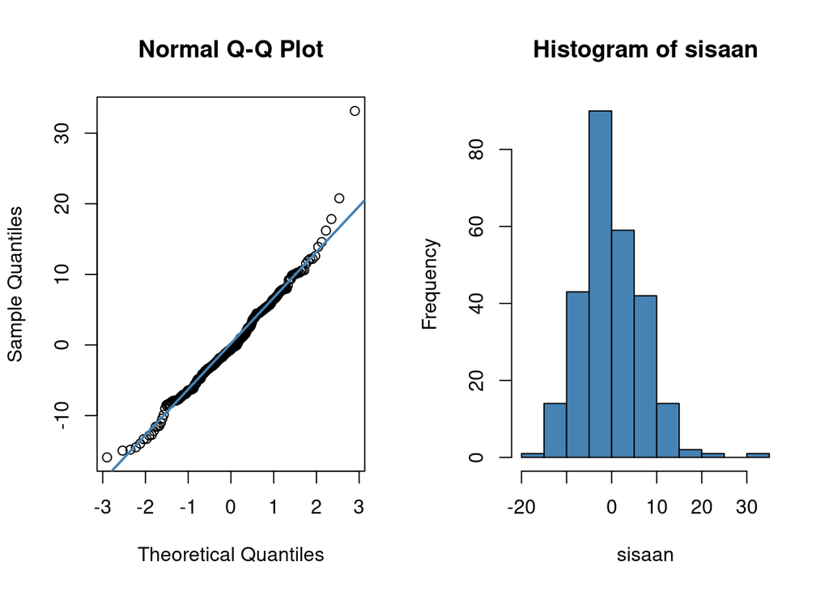

```r
#Nilai sisaan dan fitted value
sisaan<- residuals(model)
fitValue<- predict(model)

par(mfrow = c(1,2))

#QQ plot
qqnorm(sisaan)
qqline(sisaan, col = "steelblue", lwd = 2)

#Histogram
hist(sisaan, col = "steelblue")
```

QQ plot dengan titik-titik yang cenderung mengikuti garis, serta histogram dengan sebaran yang cenderung simetris dan tidak ada kemenjuluran. Kedua hal ini mengindikasikan bahwa sisaan data menyebar normal.

###Autokorelasi

Uji autokorelasi secara eksploratif menggunakan plot sisaan vs fitted value dan plot sisaan vs order

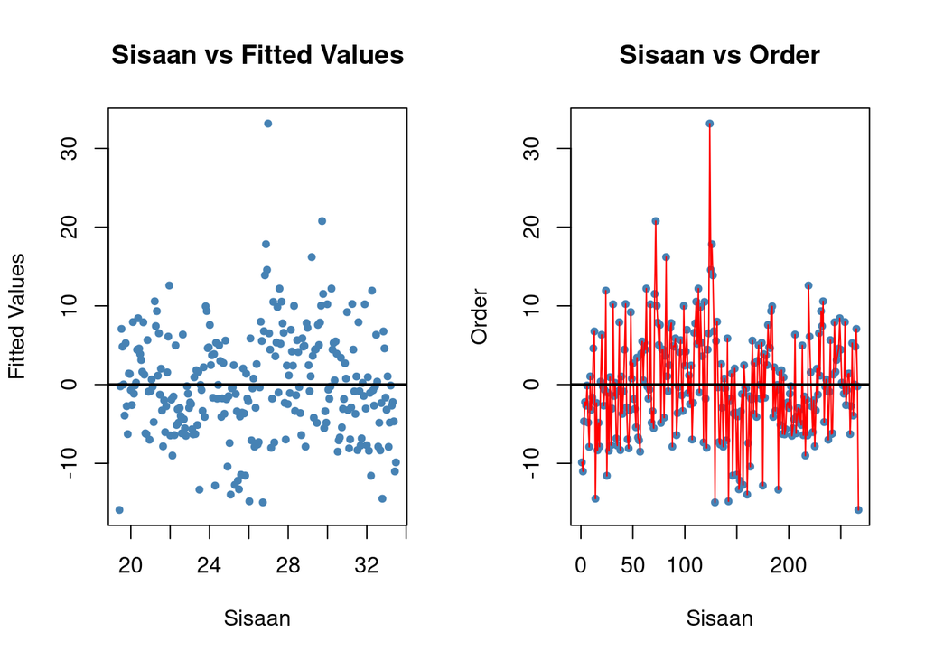

```r
par(mfrow = c(1,2))

#Plot sisaan vs fitted value
plot(fitValue, sisaan, col = "steelblue", pch = 20, xlab = "Sisaan", ylab = "Fitted Values", main = "Sisaan vs Fitted Values")
abline(a = 0, b = 0, lwd = 2)

#Plot sisaan vs order
plot(seq(1,267,1), sisaan, col = "steelblue", pch = 20, xlab = "Sisaan", ylab = "Order", main = "Sisaan vs Order")
lines(seq(1,267,1), sisaan, col = "red")
abline(a = 0, b = 0, lwd = 2)
```

##Pengujian asumsi secara formal

Untuk dapat hasil yang lebih akurat, pengujian perlu dilakukan secara formal, tidak hanya secara eksploratif saja.

###Kenormalan

Pengujian dilakukan dengan uji formal Kolmogorov-Smirnov

```r
#H0: sisaan mengikuti sebaran normal
#H1: sisaan tidak mengikuti sebaran normal

ks.test(sisaan, "pnorm", mean=mean(sisaan), sd=sd(sisaan))
```

```
##
##  Asymptotic one-sample Kolmogorov-Smirnov test
##
## data:  sisaan
## D = 0.056916, p-value = 0.3527
## alternative hypothesis: two-sided
```

Didapatkan *p-value* > $\alpha$ (5%), maka tak tolak H0. Artinya, tidak cukup bukti untuk mengatakan bahwa sisaan tidak menyebar normal. Sisaan menyebar normal.

###Autokorelasi

Pengujian dilakukan dengan uji formal Durbin-Watson

```r
#H0: tidak ada autokorelasi
#H1: ada autokorelasi

dwtest(model)
```

```
##
##  Durbin-Watson test
##
## data:  model
## DW = 1.468, p-value = 4.82e-06
## alternative hypothesis: true autocorrelation is greater than 0
```

Didapatkan *p-value* < $\alpha$ (5%), maka tolak H0. Artinya, cukup bukti untuk mengatakan bahwa ada autokorelasi.

##Penanganan autokorelasi

###Metode Cochrane-Orcutt

```r
#Penanganan Autokorelasi Cochrane-Orcutt
modelCO<-cochrane.orcutt(model)
modelCO
```

```
## Cochrane-orcutt estimation for first order autocorrelation
##
## Call:
## lm(formula = penjualan ~ pekan, data = data)
##
##  number of interaction: 3
##  rho 0.257031
##
## Durbin-Watson statistic
## (original):    1.46798 , p-value: 4.82e-06
## (transformed): 2.05083 , p-value: 6.383e-01
##
##  coefficients:
## (Intercept)       pekan
##   33.779052   -0.054464
```

Model yang terbentuk setelah penanganan adalah $y_i=33.77905-0.05446x_t$. Hasil uji Durbin-Watson setelah penanganan adalah *p-value* sebesar 0.6383 > $\alpha$ (5%), maka tak tolak H0. Artinya, tidak cukup bukti untuk menyatakan adanya autokorelasi. Data setelah penanganan sudah tidak memiliki autokorelasi.

###Transformasi manual

Menentukan nilai $ρ ̂$ optimum

```r
rho <- modelCO$rho
rho
```

```
## [1] 0.2570313
```

Transformasi manual

```r
penjualan.trans<- data$penjualan[-1]-data$penjualan[-267]*rho
pekan.trans<- pekan[-1]-pekan[-267]*rho
modelCOmanual<- lm(penjualan.trans~pekan.trans)
summary(modelCOmanual)
```

```
##
## Call:
## lm(formula = penjualan.trans ~ pekan.trans)
##
## Residuals:
##      Min       1Q   Median       3Q      Max
## -16.7362  -4.1695  -0.2714   4.4731  31.4386
##
## Coefficients:
##              Estimate Std. Error t value Pr(>|t|)
## (Intercept) 25.096778   0.806026   31.14  < 2e-16 ***
## pekan.trans -0.054464   0.006991   -7.79 1.53e-13 ***
## ---
## Signif. codes:  0 '***' 0.001 '**' 0.01 '*' 0.05 '.' 0.1 ' ' 1
##
## Residual standard error: 6.505 on 264 degrees of freedom
## Multiple R-squared:  0.1869, Adjusted R-squared:  0.1838
## F-statistic: 60.69 on 1 and 264 DF,  p-value: 1.534e-13
```

Penduga koefisien regresi pasca transformasi

```r
b0bintang <- modelCOmanual$coefficients[-2]
b0 <- b0bintang/(1-rho)
b1 <- modelCOmanual$coefficients[-1]
b0
```

```
## (Intercept)
##    33.77905
```

```r
b1
```

```
## pekan.trans
## -0.05446419
```

Model yang terbentuk sama dengan model yang dihasilkan metode Cochrane-Orcutt, yaitu $y_i=33.77905-0.05446x_t$